# Practical Machine Learning Week4

Vamshi Krishna

7/14/2020

## Introduction

One thing that people regularly do is quantify how much of a particular activity they do, but they rarely quantify how well they do it. In this project, our goal will be to use data from accelerometers on the belt, forearm, arm, and dumbell of 6 participants.

Using devices such as Jawbone Up, Nike FuelBand, and Fitbit it is now possible to collect a large amount of data about personal activity relatively inexpensively. These type of devices are part of the quantified self movement – a group of enthusiasts who take measurements about themselves regularly to improve their health, to find patterns in their behavior, or because they are tech geeks. One thing that people regularly do is quantify how much of a particular activity they do, but they rarely quantify how well they do it. In this project, your goal will be to use data from accelerometers on the belt, forearm, arm, and dumbell of 6 participants. They were asked to perform barbell lifts correctly and incorrectly in 5 different ways. More information is available from the website here: http://web.archive.org/web/20161224072740/http:/groupware.les.inf.puc-rio.br/har (see the section on the Weight Lifting Exercise Dataset).

The goal of our project is to predict the manner in which they did the exercise. This is the “classe” variable in the training set. You may use any of the other variables to predict with.

## Source of Data

The training data for this project are available here:

https://d396qusza40orc.cloudfront.net/predmachlearn/pml-training.csv

The test data are available here:

https://d396qusza40orc.cloudfront.net/predmachlearn/pml-testing.csv

## Loading the dataset and libraries required

The data for this project come from this source: http://web.archive.org/web/20161224072740/http:/groupware.les.inf.puc-rio.br/har.

Lets load the required libraries for this project and read training and testing data from the urls above and see the shape and structure of the data we are dealing with. Lets also see the head of the training data to get the idea of what data is present in it.

```r
library(caret)
```

```r
library(rpart)
library(rpart.plot)
library(RColorBrewer)
library(RGtk2)
library(rattle)
library(randomForest)
library(gbm)
library(e1071)
training = read.csv('https://d396qusza40orc.cloudfront.net/predmachlearn/pml-training.csv')
testing = read.csv('https://d396qusza40orc.cloudfront.net/predmachlearn/pml-testing.csv')
dim(training)
```

```
## [1] 19622   160
```

```r
dim(testing)
```

```
## [1]  20 160
```

```r
head(training)
```

```
##   X user_name raw_timestamp_part_1 raw_timestamp_part_2   cvtd_timestamp
## 1 1  carlitos           1323084231               788290 05/12/2011 11:23
## 2 2  carlitos           1323084231               808298 05/12/2011 11:23
## 3 3  carlitos           1323084231               820366 05/12/2011 11:23
## 4 4  carlitos           1323084232               120339 05/12/2011 11:23
## 5 5  carlitos           1323084232               196328 05/12/2011 11:23
## 6 6  carlitos           1323084232               304277 05/12/2011 11:23
##   new_window num_window roll_belt pitch_belt yaw_belt total_accel_belt
## 1         no         11      1.41       8.07    -94.4                3
## 2         no         11      1.41       8.07    -94.4                3
## 3         no         11      1.42       8.07    -94.4                3
## 4         no         12      1.48       8.05    -94.4                3
## 5         no         12      1.48       8.07    -94.4                3
## 6         no         12      1.45       8.06    -94.4                3
##   kurtosis_roll_belt kurtosis_picth_belt kurtosis_yaw_belt skewness_roll_belt
```

[output cut: 251 more lines]

```r
str(training)
```

```
## 'data.frame':    19622 obs. of  160 variables:
##  $ X                       : int  1 2 3 4 5 6 7 8 9 10 ...
##  $ user_name               : Factor w/ 6 levels "adelmo","carlitos",..: 2 2 2 2 2 2 2 2 2 2 ...
##  $ raw_timestamp_part_1    : int  1323084231 1323084231 1323084231 1323084232 1323084232 1323084232 1323084232 1323084232 1323084232 1323084232 ...
##  $ raw_timestamp_part_2    : int  788290 808298 820366 120339 196328 304277 368296 440390 484323 484434 ...
##  $ cvtd_timestamp          : Factor w/ 20 levels "02/12/2011 13:32",..: 9 9 9 9 9 9 9 9 9 9 ...
##  $ new_window              : Factor w/ 2 levels "no","yes": 1 1 1 1 1 1 1 1 1 1 ...
##  $ num_window              : int  11 11 11 12 12 12 12 12 12 12 ...
##  $ roll_belt               : num  1.41 1.41 1.42 1.48 1.48 1.45 1.42 1.42 1.43 1.45 ...
##  $ pitch_belt              : num  8.07 8.07 8.07 8.05 8.07 8.06 8.09 8.13 8.16 8.17 ...
##  $ yaw_belt                : num  -94.4 -94.4 -94.4 -94.4 -94.4 -94.4 -94.4 -94.4 -94.4 -94.4 ...
##  $ total_accel_belt        : int  3 3 3 3 3 3 3 3 3 3 ...
##  $ kurtosis_roll_belt      : Factor w/ 397 levels "","-0.016850",..: 1 1 1 1 1 1 1 1 1 1 ...
##  $ kurtosis_picth_belt     : Factor w/ 317 levels "","-0.021887",..: 1 1 1 1 1 1 1 1 1 1 ...
##  $ kurtosis_yaw_belt       : Factor w/ 2 levels "","#DIV/0!": 1 1 1 1 1 1 1 1 1 1 ...
```

[output cut: 86 more lines]

## Data cleaning

Lets clean the raw data using several methods

### Removing variables having nearly zero variance

Lets remove the variables which are near to the value of zero, as they wont me useful much using nearZeroVar

```r
near_zero_var = nearZeroVar(training)
near_zero_training = training[,-near_zero_var]
near_zero_testing = testing[,-near_zero_var]
dim(near_zero_training)
```

```
## [1] 19622   100
```

```r
dim(near_zero_testing)
```

```
## [1]  20 100
```

### Removing variables having NAs

Lets also remove the variables which are NAs

```r
na_var <- sapply(near_zero_training, function(x) mean(is.na(x))) > 0.95
na_training <- near_zero_training[,na_var == FALSE]
na_testing <- near_zero_testing[,na_var==FALSE]
dim(na_training)
```

```
## [1] 19622    59
```

```r
dim(na_testing)
```

```
## [1] 20 59
```

### Removing non-numeric variables

```r
non_num_training <- na_training[,8:59]
non_num_testing <- na_testing[,8:59]
dim(non_num_training)
```

```
## [1] 19622    52
```

```r
dim(non_num_testing)
```

```
## [1] 20 52
```

The final data after cleaning the raw data we get are non_num_training and non_num_testing and see their dimensions

## Creating Data Partitioning

Now, lets partition the data using createDataPartition method with 60% as training data and 40% as testing data and store them in train and test dataframes and see their size

```r
inTrain <- createDataPartition(non_num_training$classe, p=0.6, list=FALSE)
train <- non_num_training[inTrain,]
test <- non_num_training[-inTrain,]
dim(train)
```

```
## [1] 11776    52
```

```r
dim(test)
```

```
## [1] 7846   52
```

Lets check if classe column is present in training dataset and problem_id in testing dataset (raw data)

```r
'classe' %in% names(training)
```

```
## [1] TRUE
```

```r
'problem_id' %in% names(testing)
```

```
## [1] TRUE
```

## Fitting model using Decision Tree

Lets first fit the model using decision tree on our data and predict the values of test data and create a confusion matrix and finally plot a decision tree using rpart.plot

```r
DTree_fit <- train(classe ~ ., data = train, method="rpart")
DTree_pred <- predict(DTree_fit, test)
confusionMatrix(DTree_pred, test$classe)
```

```
## Confusion Matrix and Statistics
##
##           Reference
## Prediction    A    B    C    D    E
##          A 2037  600  619  565  363
##          B   33  530   44  225  292
##          C  128  333  553  164  335
##          D   32   54  152  332   64
##          E    2    1    0    0  388
##
## Overall Statistics
##
##                Accuracy : 0.4894
##                  95% CI : (0.4783, 0.5005)
##     No Information Rate : 0.2845
##     P-Value [Acc > NIR] : < 2.2e-16
##
##                   Kappa : 0.3322
##
##  Mcnemar's Test P-Value : < 2.2e-16
##
## Statistics by Class:
##
##                      Class: A Class: B Class: C Class: D Class: E
## Sensitivity            0.9126  0.34914  0.40424  0.25816  0.26907
## Specificity            0.6176  0.90613  0.85181  0.95396  0.99953
## Pos Pred Value         0.4869  0.47153  0.36550  0.52366  0.99233
## Neg Pred Value         0.9468  0.85302  0.87131  0.86772  0.85862
## Prevalence             0.2845  0.19347  0.17436  0.16391  0.18379
## Detection Rate         0.2596  0.06755  0.07048  0.04231  0.04945
## Detection Prevalence   0.5333  0.14326  0.19284  0.08081  0.04983
## Balanced Accuracy      0.7651  0.62764  0.62802  0.60606  0.63430
```

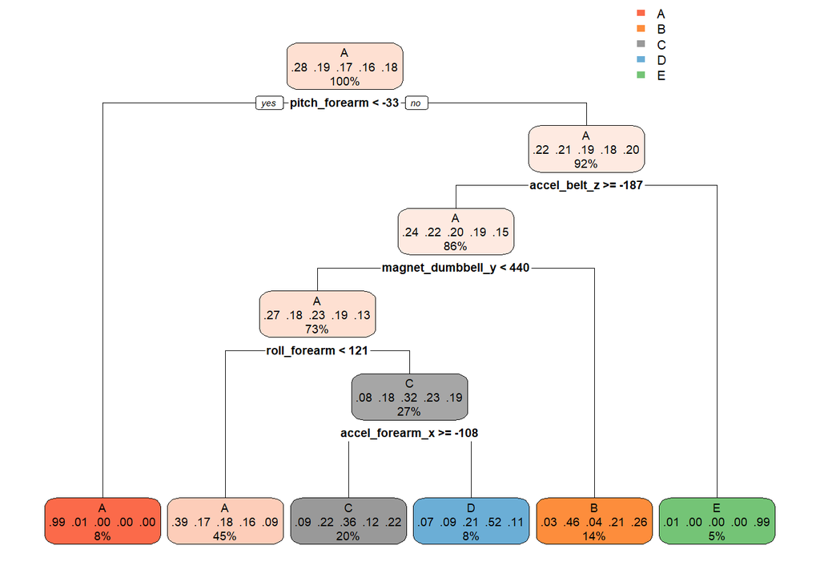

```r
rpart.plot(DTree_fit$finalModel, roundint=FALSE)
```

## Fitting model using Gradient Boosting

```r
GBM_fit <- train(classe ~ ., data = train, method = "gbm", verbose = FALSE)
GBM_fit$finalModel
```

```
## A gradient boosted model with multinomial loss function.
## 150 iterations were performed.
## There were 51 predictors of which 51 had non-zero influence.
```

```r
GBM_pred <- predict(GBM_fit, test)
GBM_pred_conf <- confusionMatrix(GBM_pred, test$classe)
GBM_pred_conf
```

```
## Confusion Matrix and Statistics
##
##           Reference
## Prediction    A    B    C    D    E
##          A 2208   40    0    1    3
##          B   19 1441   54    8   27
##          C    2   29 1298   37   16
##          D    3    1   14 1230   18
##          E    0    7    2   10 1378
##
## Overall Statistics
##
##                Accuracy : 0.9629
##                  95% CI : (0.9585, 0.967)
##     No Information Rate : 0.2845
##     P-Value [Acc > NIR] : < 2.2e-16
##
##                   Kappa : 0.9531
##
##  Mcnemar's Test P-Value : 1.68e-09
##
## Statistics by Class:
##
##                      Class: A Class: B Class: C Class: D Class: E
## Sensitivity            0.9892   0.9493   0.9488   0.9565   0.9556
## Specificity            0.9922   0.9829   0.9870   0.9945   0.9970
## Pos Pred Value         0.9805   0.9303   0.9392   0.9716   0.9864
## Neg Pred Value         0.9957   0.9878   0.9892   0.9915   0.9901
## Prevalence             0.2845   0.1935   0.1744   0.1639   0.1838
## Detection Rate         0.2814   0.1837   0.1654   0.1568   0.1756
## Detection Prevalence   0.2870   0.1974   0.1761   0.1614   0.1781
## Balanced Accuracy      0.9907   0.9661   0.9679   0.9755   0.9763
```

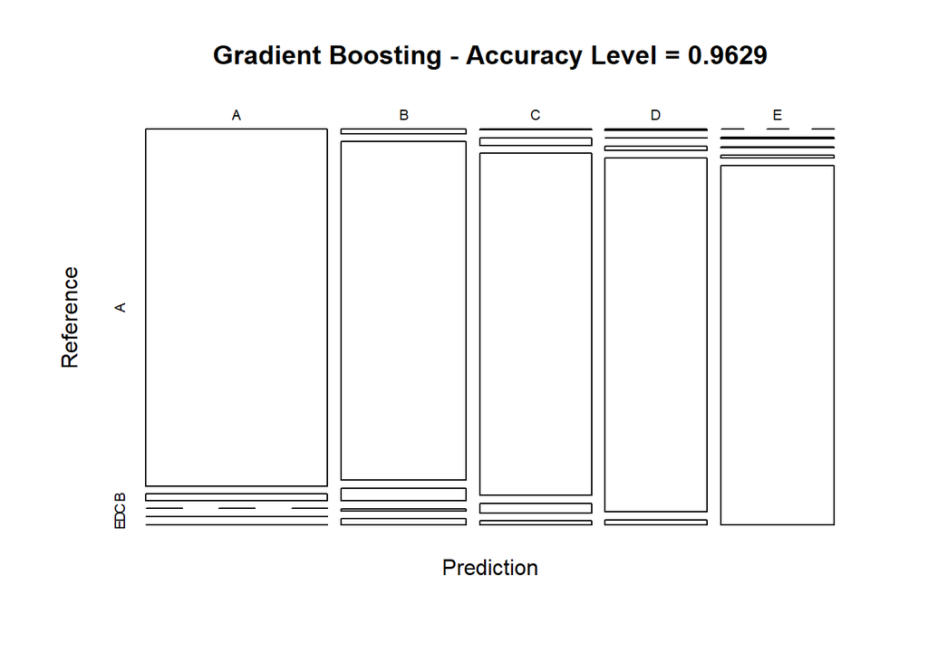

```r
plot(GBM_pred_conf$table, col = GBM_pred_conf$byClass,
main = paste("Gradient Boosting - Accuracy Level =",
round(GBM_pred_conf$overall['Accuracy'], 4)))
```

## Fitting model using Random Forest

```r
RF_fit <- train(classe ~ ., data = train, method = "rf", ntree = 50)
RF_pred <- predict(RF_fit, test)
RF_pred_conf <- confusionMatrix(RF_pred, test$classe)
RF_pred_conf
```

```
## Confusion Matrix and Statistics
##
##           Reference
## Prediction    A    B    C    D    E
##          A 2230   11    0    0    0
##          B    2 1497    9    0    0
##          C    0    9 1356   15    4
##          D    0    0    2 1269    6
##          E    0    1    1    2 1432
##
## Overall Statistics
##
##                Accuracy : 0.9921
##                  95% CI : (0.9899, 0.9939)
##     No Information Rate : 0.2845
##     P-Value [Acc > NIR] : < 2.2e-16
##
##                   Kappa : 0.99
##
##  Mcnemar's Test P-Value : NA
##
## Statistics by Class:
##
##                      Class: A Class: B Class: C Class: D Class: E
## Sensitivity            0.9991   0.9862   0.9912   0.9868   0.9931
## Specificity            0.9980   0.9983   0.9957   0.9988   0.9994
## Pos Pred Value         0.9951   0.9927   0.9798   0.9937   0.9972
## Neg Pred Value         0.9996   0.9967   0.9981   0.9974   0.9984
## Prevalence             0.2845   0.1935   0.1744   0.1639   0.1838
## Detection Rate         0.2842   0.1908   0.1728   0.1617   0.1825
## Detection Prevalence   0.2856   0.1922   0.1764   0.1628   0.1830
## Balanced Accuracy      0.9986   0.9922   0.9935   0.9928   0.9962
```

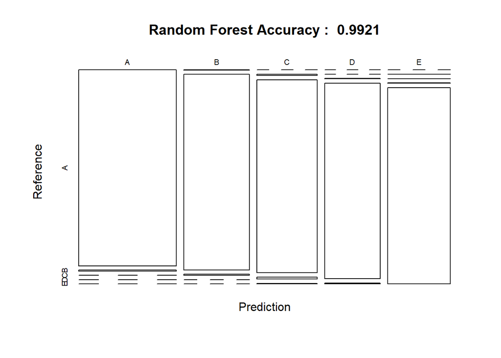

```r
plot(RF_pred_conf$table, col = RF_pred_conf$byClass,
main = paste("Random Forest Accuracy : ",
round(RF_pred_conf$overall['Accuracy'], 4)))
```

## Conclusion and Summary

As decision tree model’s accuracy was very low, we completely ignore that model and concentrate on the other two models’ accuracy.

```r
RF_pred_conf$overall
```

```
##       Accuracy          Kappa  AccuracyLower  AccuracyUpper   AccuracyNull
##      0.9920979      0.9900035      0.9898811      0.9939363      0.2844762
## AccuracyPValue  McnemarPValue
##      0.0000000            NaN
```

```r
GBM_pred_conf$overall
```

```
##       Accuracy          Kappa  AccuracyLower  AccuracyUpper   AccuracyNull
##   9.629110e-01   9.530679e-01   9.584902e-01   9.669836e-01   2.844762e-01
## AccuracyPValue  McnemarPValue
##   0.000000e+00   1.680062e-09
```

After looking at the overall statistics data of both the models, the random Forest model has more accuracy than the GBM model. So, we are selecting Random Forest model for final prediction of testing data.

## Final modelling and prediction on actual Test data

```r
training_data = non_num_training
testing_data = non_num_testing
RF_final_fit <- train(classe ~ ., data = training_data, method = "rf", ntree = 50)
final_pred <- predict(RF_final_fit, testing_data)
final_pred
```

```
##  [1] B A B A A E D B A A B C B A E E A B B B
## Levels: A B C D E
```